# AllLifeBank

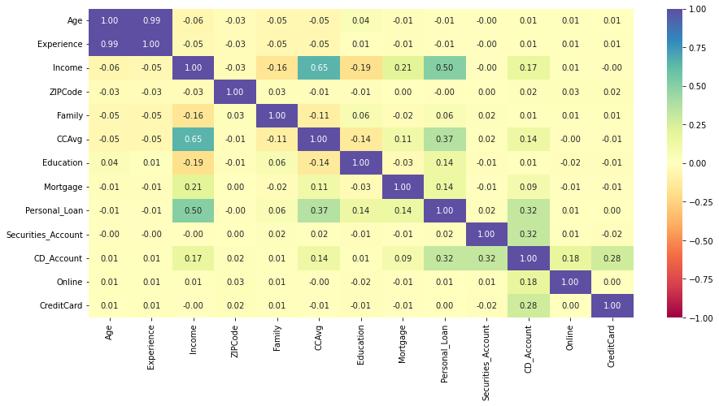

```python
plt.figure(figsize=(15, 7))
sns.heatmap(AllBankData.corr(), annot=True, vmin=-1, vmax=1, fmt=".2f", cmap="Spectral")
plt.show()
```

```python
def stacked_barplot(data, predictor, target):
    """
    Print the category counts and plot a stacked bar chart

    data: dataframe
    predictor: independent variable
    target: target variable
    """
    count = data[predictor].nunique()
    sorter = data[target].value_counts().index[-1]
    tab1 = pd.crosstab(data[predictor], data[target], margins=True).sort_values(
        by=sorter, ascending=False
    )
    print(tab1)
    print("-" * 120)
    tab = pd.crosstab(data[predictor], data[target], normalize="index").sort_values(
        by=sorter, ascending=False
    )
    tab.plot(kind="bar", stacked=True, figsize=(count + 5, 5))
    plt.legend(
        loc="lower left", frameon=False,
    )
    plt.legend(loc="upper left", bbox_to_anchor=(1, 1))
    plt.show()
```

```
Personal_Loan     0    1   All
Age
All            4468  480  4948
34              116   18   134
30              119   17   136
36               91   16   107
63               92   16   108
35              135   16   151
33              105   15   120
52              130   15   145
54              128   15   143
29              105   15   120
43              134   15   149
42              112   14   126
56              121   14   135
```

[output cut: 33 more lines]

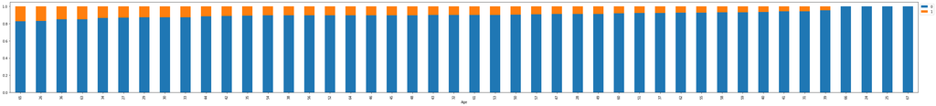

```
Personal_Loan     0    1   All
Experience
All            4468  480  4948
9               127   20   147
8               101   18   119
3               112   17   129
20              131   17   148
12               86   16   102
5               132   14   146
32              140   14   154
26              120   14   134
25              128   14   142
19              121   14   135
16              114   13   127
37              103   13   116
```

[output cut: 33 more lines]

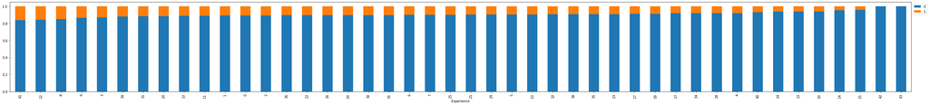

```
Personal_Loan     0    1   All
Income
All            4468  480  4948
130               8   11    19
182               2   11    13
158               8   10    18
135               7   10    17
...             ...  ...   ...
41               81    0    81
40               77    0    77
39               79    0    79
38               82    0    82
8                23    0    23

[163 rows x 3 columns]
------------------------------------------------------------------------------------------------------------------------
```

[figure not shown]

```
Personal_Loan     0    1   All
ZIPCode
All            4468  480  4948
94720           145   19   164
94305           112   13   125
92093            42    9    51
90095            63    8    71
...             ...  ...   ...
92866             8    0     8
92843             3    0     3
92835             2    0     2
92833             4    0     4
90005             5    0     5

[468 rows x 3 columns]
------------------------------------------------------------------------------------------------------------------------
```

[figure not shown]

```
Personal_Loan     0    1   All
Family
All            4468  480  4948
4              1069  134  1203
3               868  133  1001
1              1363  107  1470
2              1168  106  1274
------------------------------------------------------------------------------------------------------------------------
```

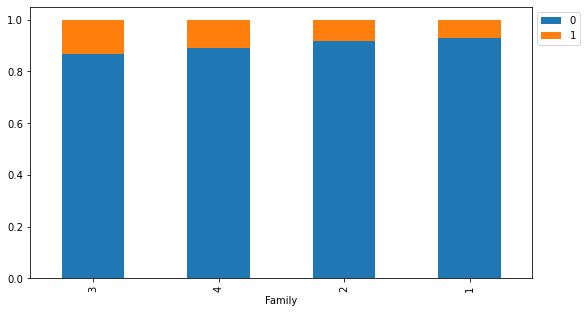

```
Personal_Loan     0    1   All
CCAvg
All            4468  480  4948
3.0              34   19    53
4.1               9   13    22
3.4              26   13    39
3.1               8   12    20
...             ...  ...   ...
1.67             18    0    18
1.75              5    0     5
7.8               9    0     9
7.6               9    0     9
2.33             18    0    18

[109 rows x 3 columns]
------------------------------------------------------------------------------------------------------------------------
```

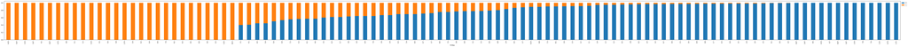

```
Personal_Loan     0    1   All
Education
All            4468  480  4948
3              1276  205  1481
2              1205  182  1387
1              1987   93  2080
------------------------------------------------------------------------------------------------------------------------
```

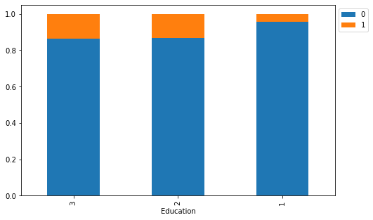

```
Personal_Loan     0    1   All
Mortgage
All            4468  480  4948
0              3110  312  3422
301               0    5     5
342               1    3     4
282               0    3     3
...             ...  ...   ...
276               2    0     2
156               5    0     5
278               1    0     1
280               2    0     2
248               3    0     3

[348 rows x 3 columns]
------------------------------------------------------------------------------------------------------------------------
```

[figure not shown]

```
Personal_Loan          0    1   All
Securities_Account
All                 4468  480  4948
0                   4012  420  4432
1                    456   60   516
------------------------------------------------------------------------------------------------------------------------
```

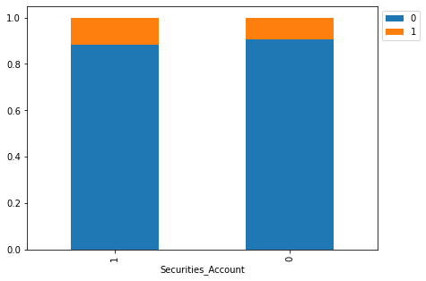

```
Personal_Loan     0    1   All
CD_Account
All            4468  480  4948
0              4306  340  4646
1               162  140   302
------------------------------------------------------------------------------------------------------------------------
```

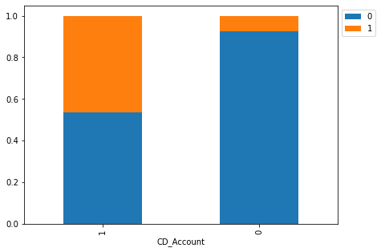

```
Personal_Loan     0    1   All
Online
All            4468  480  4948
1              2663  291  2954
0              1805  189  1994
------------------------------------------------------------------------------------------------------------------------
```

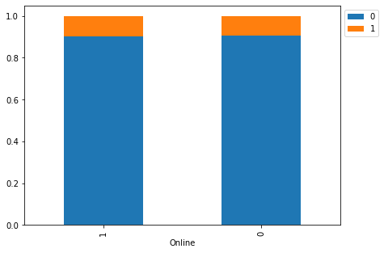

```
Personal_Loan     0    1   All
CreditCard
All            4468  480  4948
0              3156  337  3493
1              1312  143  1455
------------------------------------------------------------------------------------------------------------------------
```

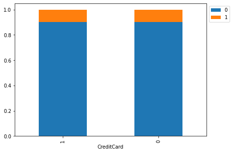

```python
cols = ['Age','Experience','Income','ZIPCode','Family','CCAvg','Education','Mortgage','Securities_Account','CD_Account','Online','CreditCard']

for i in cols:
    stacked_barplot(AllBankData, i,"Personal_Loan")
```

## Illustrate the insights based on EDA

### Observations from UniVariant Analysis

- Age - Most of the customers are from age 35 to 55
- Income - Most of the customer's income is less than 100k and observed few outliers. Outliers need more investigation during the data preprocessing. Income is right-skewed.
- ZIPCode - more than 50% of zipcode area's customers didnt accept loan. Bank can focus these areas people to expand their business.
- Family - Three-member family count is lesser than others. Single person count is higher than others
- CCAvg - This is right-skewed and it has a lot of outliers. Most of the customers are spending amounts on credit cards average from 0.5 to 3 thousand in a month
- Education - All customers are educated. The undergraduate count must be from 2000 to 2250. Graduates and professionals count must be from 1250 to 1500
- Mortgage - 3462 customers have no mortgage. customers who have Mortgage loans mostly from 0.5 to 100 thousand.
- Personal_Loan - 4520 customers didn't accept personal loan from the last campaign. So the bank can focus on these customers.
- Securities_Account - 4478 customers have no security deposit in the bank
- CD_Account - 4698 customers have no CD_Account
- Online - 2016 customers have no online account
- CreditCard - 3530 customers have no credit cards (Excluding from AllLifeBank). The rest of the customers 1470 are having credit cards in other banks.

### Overall Comments

- Personal_Loan slightly correlated with Income, CCAvg, CD_Account. Hence these three variables are going to impact the personal_Loan
- No correlation between CreditCard and Personal_Loan
- Very less correlation between Personal_Loan with Online, Securities_Account, Mortgage, Education
- Age and Experience very slight negative correlated with Personal_Loan (-0.01)
- Only 480 customers accepted personal loans from the last campaign

## Data Pre-Processing

```python
# To see any negative values in each columns
(AllBankData<0).sum()
```

```
Age                    0
Experience            52
Income                 0
ZIPCode                0
Family                 0
CCAvg                  0
Education              0
Mortgage               0
Personal_Loan          0
Securities_Account     0
CD_Account             0
Online                 0
CreditCard             0
dtype: int64
```

**Only Experience column has negative values in 52 records

```python
#To check any other column has 0 which is going to lead problem during model build.
(AllBankData==0).sum()
```

```
Age                      0
Experience              66
Income                   0
ZIPCode                  0
Family                   0
CCAvg                  106
Education                0
Mortgage              3462
Personal_Loan         4520
Securities_Account    4478
CD_Account            4698
Online                2016
CreditCard            3530
dtype: int64
```

- Experience has 0 values in 66 records. but it indicates that 66 customers have no work experience. Hence these all are valid records
- CCvg has 0 values in 106 records. It indicates that 106 customers not spending any amount from the credit card that using by other banks
- Mortgage, Personal_Loan, Securities_Account,CD_Account, Online and CreditCard columns have 0 but these all are valid records. Hence no data pre-processing is required.
- We have already verified the missing values and duplicates during the data review section above. There is no duplicate and missing records.

#### To verify any negative value or zero or ? in variables

```python
AllBankData['Income'].unique()
```

```
array([ 49,  34,  11, 100,  45,  29,  72,  22,  81, 180, 105, 114,  40,
       112, 130, 193,  21,  25,  63,  62,  43, 152,  83, 158,  48, 119,
        35,  41,  18,  50, 121,  71, 141,  80,  84,  60, 132, 104,  52,
       194,   8, 131, 190,  44, 139,  93, 188,  39, 125,  32,  20, 115,
        69,  85, 135,  12, 133,  19,  82, 109,  42,  78,  51, 113, 118,
        64, 161,  94,  15,  74,  30,  38,   9,  92,  61,  73,  70, 149,
        98, 128,  31,  58,  54, 124, 163,  24,  79, 134,  23,  13, 138,
       171, 168,  65,  10, 148, 159, 169, 144, 165,  59,  68,  91, 172,
        55, 155,  53,  89,  28,  75, 170, 120,  99, 111,  33, 129, 122,
       150, 195, 110, 101, 191, 140, 153, 173, 174,  90, 179, 145, 200,
       183, 182,  88, 160, 205, 164,  14, 175, 103, 108, 185, 204, 154,
       102, 192, 202, 162, 142,  95, 184, 181, 143, 123, 178, 198, 201,
       203, 189, 151, 199, 224, 218], dtype=int64)
```

```python
AllBankData['Experience'].unique()
```

```
array([ 1, 19, 15,  9,  8, 13, 27, 24, 10, 39,  5, 23, 32, 41, 30, 14, 18,
       21, 28, 31, 11, 16, 20, 35,  6, 25,  7, 12, 26, 37, 17,  2, 36, 29,
        3, 22, -1, 34,  0, 38, 40, 33,  4, -2, 42, -3, 43], dtype=int64)
```

```python
AllBankData['Age'].unique()
```

```
array([25, 45, 39, 35, 37, 53, 50, 34, 65, 29, 48, 59, 67, 60, 38, 42, 46,
       55, 56, 57, 44, 36, 43, 40, 30, 31, 51, 32, 61, 41, 28, 49, 47, 62,
       58, 54, 33, 27, 66, 24, 52, 26, 64, 63, 23], dtype=int64)
```

```python
AllBankData['ZIPCode'].unique()
```

```
array([91107, 90089, 94720, 94112, 91330, 92121, 91711, 93943, 93023,
       94710, 90277, 93106, 94920, 91741, 95054, 95010, 94305, 91604,
       94015, 90095, 91320, 95521, 95064, 90064, 94539, 94104, 94117,
       94801, 94035, 92647, 95814, 94114, 94115, 92672, 94122, 90019,
       95616, 94065, 95014, 91380, 95747, 92373, 92093, 94005, 90245,
       95819, 94022, 90404, 93407, 94523, 90024, 91360, 95670, 95123,
       90045, 91335, 93907, 92007, 94606, 94611, 94901, 92220, 93305,
       95134, 94612, 92507, 91730, 94501, 94303, 94105, 94550, 92612,
       95617, 92374, 94080, 94608, 93555, 93311, 94704, 92717, 92037,
       95136, 94542, 94143, 91775, 92703, 92354, 92024, 92831, 92833,
       94304, 90057, 92130, 91301, 92096, 92646, 92182, 92131, 93720,
       90840, 95035, 93010, 94928, 95831, 91770, 90007, 94102, 91423,
       93955, 94107, 92834, 93117, 94551, 94596, 94025, 94545, 95053,
       90036, 91125, 95120, 94706, 95827, 90503, 90250, 95817, 95503,
       93111, 94132, 95818, 91942, 90401, 93524, 95133, 92173, 94043,
```

[output cut: 38 more lines]

```python
AllBankData['Family'].unique()
```

```
array([4, 3, 1, 2], dtype=int64)
```

### To find mean, median, Q1 and Q3 to replace the negative values in experience column

##### Lets check which is best to treat the negative values

```python
#To find median value from Experience column
AllBankData['Experience'].median()
```

```
20.0
```

```python
#To find mean value from Experience column
AllBankData['Experience'].mean()
```

```
20.1046
```

```python
#To find Q1 and Q3 from Experience column
quartiles = np.quantile(AllBankData['Experience'][AllBankData['Experience'].notnull()], [.25, .75])
power_4iqr = 4 * (quartiles[1] - quartiles[0])
print(f'Q1 = {quartiles[0]}, Q3 = {quartiles[1]}, 4*IQR = {power_4iqr}')
outliers = AllBankData.loc[np.abs(AllBankData['Experience'] - AllBankData['Experience'].median()) > power_4iqr, i]
#outliers
print(outliers.count)
```

```
Q1 = 10.0, Q3 = 30.0, 4*IQR = 80.0
<bound method Series.count of Series([], Name: CreditCard, dtype: int64)>
```

```python
AllBankData.drop(AllBankData[AllBankData['Experience']<0].index,inplace=True)

AllBankData['Experience'].count()
```

```
4948
```

### Summary of Data Pre-Processing

- All column values are int and float data types. so not required to do any typecast
- There are no duplicate and missing values in columns
- Only the Experience column had negative values. Those are deleted
- Total row count reduced to 4948 from 5000 after removed rows

## Build Logistic regression model

```python
#Create split for traning and test. X = Other than Personal_Loan (dependent variables), Y = Personal_Loan (target variable)

X = AllBankData.drop(["Personal_Loan"], axis=1)
Y = AllBankData["Personal_Loan"]

X = pd.get_dummies(X, drop_first=True)

# Splitting data in train and test sets
X_train, X_test, y_train, y_test = train_test_split(
    X, Y, test_size=0.30, random_state=1
)
```

```python
#To display traning and test %

print("Shape of Training set : ", X_train.shape)
print("Shape of test set : ", X_test.shape)
print("Percentage of classes in training set:")
print(y_train.value_counts(normalize=True))
print("Percentage of classes in test set:")
print(y_test.value_counts(normalize=True))
```

```
Shape of Training set :  (3463, 12)
Shape of test set :  (1485, 12)
Percentage of classes in training set:
0    0.903263
1    0.096737
Name: Personal_Loan, dtype: float64
Percentage of classes in test set:
0    0.902357
1    0.097643
Name: Personal_Loan, dtype: float64
```

```python
# defining a function to compute different metrics to check performance of a classification model built using sklearn

def model_performance_classification_sklearn_with_threshold(model, predictors, target, threshold=0.5):
    """
    Function to compute different metrics, based on the threshold specified, to check classification model performance

    model: classifier
    predictors: independent variables
    target: dependent variable
    threshold: threshold for classifying the observation as class 1
    """

    # predicting using the independent variables
    pred_prob = model.predict_proba(predictors)[:, 1]
    pred_thres = pred_prob > threshold
    pred = np.round(pred_thres)

    acc = accuracy_score(target, pred)  # to compute Accuracy
    recall = recall_score(target, pred)  # to compute Recall
    precision = precision_score(target, pred)  # to compute Precision
    f1 = f1_score(target, pred)  # to compute F1-score

    # creating a dataframe of metrics
    df_perf = pd.DataFrame(
        {
            "Accuracy": acc,
            "Recall": recall,
            "Precision": precision,
            "F1": f1,
        },
        index=[0],
    )

    return df_perf
```

```python
# defining a function to plot the confusion_matrix of a classification model built using sklearn
def confusion_matrix_sklearn_with_threshold(model, predictors, target, threshold=0.5):
    """
    To plot the confusion_matrix, based on the threshold specified, with percentages

    model: classifier
    predictors: independent variables
    target: dependent variable
    threshold: threshold for classifying the observation as class 1
    """
    pred_prob = model.predict_proba(predictors)[:, 1]
    pred_thres = pred_prob > threshold
    y_pred = np.round(pred_thres)

    cm = confusion_matrix(target, y_pred)
    labels = np.asarray(
        [
            ["{0:0.0f}".format(item) + "\n{0:.2%}".format(item / cm.flatten().sum())]
            for item in cm.flatten()
        ]
    ).reshape(2, 2)

    plt.figure(figsize=(6, 4))
    sns.heatmap(cm, annot=labels, fmt="")
    plt.ylabel("True label")
    plt.xlabel("Predicted label")
```

```python
#Logistic regression

lg = LogisticRegression(solver="newton-cg", random_state=1)
model = lg.fit(X_train, y_train)
```

```python
# let us check the coefficients and intercept of the model

coef_df = pd.DataFrame(
    np.append(lg.coef_, lg.intercept_),
    index=X_train.columns.tolist() + ["Intercept"],
    columns=["Coefficients"],
)
coef_df.T
```

|  | Age | Experience | Income | ZIPCode | Family | CCAvg | Education | Mortgage | Securities_Account | CD_Account | Online | CreditCard | Intercept |
| --- | --- | --- | --- | --- | --- | --- | --- | --- | --- | --- | --- | --- | --- |
| Coefficients | -0.129622 | 0.136516 | 0.051769 | -0.0001 | 0.647657 | 0.125913 | 1.599359 | 0.00095 | -0.498127 | 3.251438 | -0.589959 | -1.032673 | -0.255658 |

### Coefficient interpretations

- Age, ZIPCode, Securities_Account, Online, CreditCard are negative, increase in these will decrease the chances of customer personal loan
- Coffient of Experience, Income, Family, CCAvg, Education, Mortgage are positive, increase in these values will increase the chances of personal loan

### Converting coefficients to odds

- The coefficients of the logistic regression model are in terms of log(odd), to find the odds we have to take the exponential of the coefficients.
- Therefore, odds = exp(b)
- The percentage change in odds is given as odds = (exp(b) - 1) * 100

```python
# converting coefficients to odds
odds = np.exp(lg.coef_[0])

# finding the percentage change
perc_change_odds = (np.exp(lg.coef_[0]) - 1) * 100

# removing limit from number of columns to display
pd.set_option("display.max_columns", None)

# adding the odds to a dataframe
pd.DataFrame({"Odds": odds, "Change_odd%": perc_change_odds}, index=X_train.columns).T
```

|  | Age | Experience | Income | ZIPCode | Family | CCAvg | Education | Mortgage | Securities_Account | CD_Account | Online | CreditCard |
| --- | --- | --- | --- | --- | --- | --- | --- | --- | --- | --- | --- | --- |
| Odds | 0.878428 | 1.146274 | 1.053133 | 0.999900 | 1.911058 | 1.134184 | 4.949860 | 1.000950 | 0.607668 | 25.827457 | 0.554350 | 0.356054 |
| Change_odd% | -12.157241 | 14.627362 | 5.313285 | -0.009989 | 91.105799 | 13.418352 | 394.986038 | 0.095021 | -39.233248 | 2482.745715 | -44.565004 | -64.394608 |

## Model performance evaluation and improvement - Logistic Regression

### Checking model performance on training set

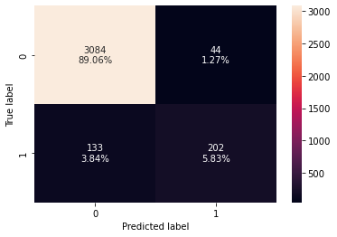

```python
# creating confusion matrix
confusion_matrix_sklearn_with_threshold(lg, X_train, y_train)
```

```python
log_reg_model_train_perf = model_performance_classification_sklearn_with_threshold(
    lg, X_train, y_train
)

print("Training performance:")
log_reg_model_train_perf
```

```
Training performance:
```

|  | Accuracy | Recall | Precision | F1 |
| --- | --- | --- | --- | --- |
| 0 | 0.948888 | 0.602985 | 0.821138 | 0.695353 |

### Checking model performance on test set

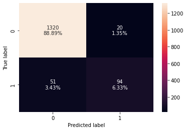

```python
# creating confusion matrix
confusion_matrix_sklearn_with_threshold(lg, X_test, y_test)
```

```python
log_reg_model_test_perf = model_performance_classification_sklearn_with_threshold(
    lg, X_test, y_test
)

print("Test set performance:")
log_reg_model_test_perf
```

```
Test set performance:
```

|  | Accuracy | Recall | Precision | F1 |
| --- | --- | --- | --- | --- |
| 0 | 0.952189 | 0.648276 | 0.824561 | 0.725869 |

### ROC - AUC

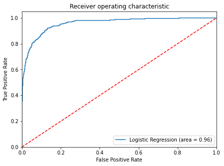

```python
#ROC - AUC on training set

logit_roc_auc_train = roc_auc_score(y_train, lg.predict_proba(X_train)[:, 1])
fpr, tpr, thresholds = roc_curve(y_train, lg.predict_proba(X_train)[:, 1])
plt.figure(figsize=(7, 5))
plt.plot(fpr, tpr, label="Logistic Regression (area = %0.2f)" % logit_roc_auc_train)
plt.plot([0, 1], [0, 1], "r--")
plt.xlim([0.0, 1.0])
plt.ylim([0.0, 1.05])
plt.xlabel("False Positive Rate")
plt.ylabel("True Positive Rate")
plt.title("Receiver operating characteristic")
plt.legend(loc="lower right")
plt.show()
```

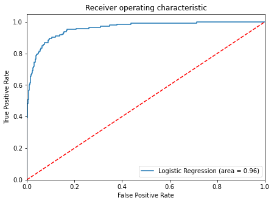

```python
#ROC - AUC on test set

logit_roc_auc_test = roc_auc_score(y_test, lg.predict_proba(X_test)[:, 1])
fpr, tpr, thresholds = roc_curve(y_test, lg.predict_proba(X_test)[:, 1])
plt.figure(figsize=(7, 5))
plt.plot(fpr, tpr, label="Logistic Regression (area = %0.2f)" % logit_roc_auc_test)
plt.plot([0, 1], [0, 1], "r--")
plt.xlim([0.0, 1.0])
plt.ylim([0.0, 1.05])
plt.xlabel("False Positive Rate")
plt.ylabel("True Positive Rate")
plt.title("Receiver operating characteristic")
plt.legend(loc="lower right")
plt.show()
```

```python
# Optimal threshold as per AUC-ROC curve
# The optimal cut off would be where tpr is high and fpr is low
fpr, tpr, thresholds = roc_curve(y_train, lg.predict_proba(X_train)[:, 1])

optimal_idx = np.argmax(tpr - fpr)
optimal_threshold_auc_roc = thresholds[optimal_idx]
print(optimal_threshold_auc_roc)
```

```
0.07883171724213994
```

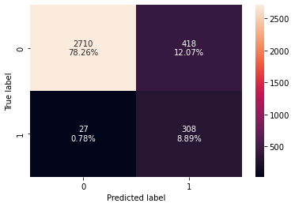

```python
# creating confusion matrix on training set with auc roc
confusion_matrix_sklearn_with_threshold(
    lg, X_train, y_train, threshold=optimal_threshold_auc_roc
)
```

### Checking model performance on training set with auc_roc

```python
# checking model performance for this model
log_reg_model_train_perf_threshold_auc_roc = model_performance_classification_sklearn_with_threshold(
    lg, X_train, y_train, threshold=optimal_threshold_auc_roc
)
print("Training performance:")
log_reg_model_train_perf_threshold_auc_roc
```

```
Training performance:
```

|  | Accuracy | Recall | Precision | F1 |
| --- | --- | --- | --- | --- |
| 0 | 0.871499 | 0.919403 | 0.424242 | 0.580584 |

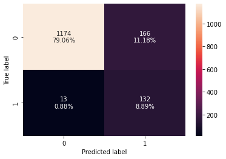

```python
# creating confusion matrix on test set with auc roc
confusion_matrix_sklearn_with_threshold(
    lg, X_test, y_test, threshold=optimal_threshold_auc_roc
)
```

### checking model performance on test set with auc_roc

```python
# checking model performance for this model
log_reg_model_test_perf_threshold_auc_roc = model_performance_classification_sklearn_with_threshold(
    lg, X_test, y_test, threshold=optimal_threshold_auc_roc
)
print("Test set performance:")
log_reg_model_test_perf_threshold_auc_roc
```

```
Test set performance:
```

|  | Accuracy | Recall | Precision | F1 |
| --- | --- | --- | --- | --- |
| 0 | 0.879461 | 0.910345 | 0.442953 | 0.595937 |

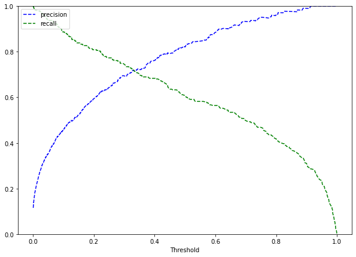

```python
y_scores = lg.predict_proba(X_train)[:, 1]
prec, rec, tre = precision_recall_curve(y_train, y_scores,)


def plot_prec_recall_vs_tresh(precisions, recalls, thresholds):
    plt.plot(thresholds, precisions[:-1], "b--", label="precision")
    plt.plot(thresholds, recalls[:-1], "g--", label="recall")
    plt.xlabel("Threshold")
    plt.legend(loc="upper left")
    plt.ylim([0, 1])


plt.figure(figsize=(10, 7))
plot_prec_recall_vs_tresh(prec, rec, tre)
plt.show()
```

- At the threshold of 0.32, we get balanced recall and precision.

```python
# setting the threshold
optimal_threshold_curve = 0.32
```

### Confusion matrix with fixed threshold

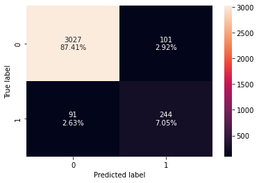

```python
# creating confusion matrix
confusion_matrix_sklearn_with_threshold(
    lg, X_train, y_train, threshold=optimal_threshold_curve
)
```

### Checking performace on training set with fixed thresold

```python
# Check performace on training set after set the thresold value

log_reg_model_train_perf_threshold_curve = model_performance_classification_sklearn_with_threshold(
    lg, X_train, y_train, threshold=optimal_threshold_curve
)
print("Training performance:")
log_reg_model_train_perf_threshold_curve
```

```
Training performance:
```

|  | Accuracy | Recall | Precision | F1 |
| --- | --- | --- | --- | --- |
| 0 | 0.944557 | 0.728358 | 0.707246 | 0.717647 |

### Checking performace on test set with fixed thresold

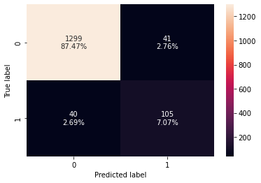

```python
# creating confusion matrix
confusion_matrix_sklearn_with_threshold(
    lg, X_test, y_test, threshold=optimal_threshold_curve
)
```

```python
# Check performace on test set after set the thresold value

log_reg_model_test_perf_threshold_curve = model_performance_classification_sklearn_with_threshold(
    lg, X_test, y_test, threshold=optimal_threshold_curve
)
print("Test set performance:")
log_reg_model_test_perf_threshold_curve
```

```
Test set performance:
```

|  | Accuracy | Recall | Precision | F1 |
| --- | --- | --- | --- | --- |
| 0 | 0.945455 | 0.724138 | 0.719178 | 0.721649 |

### Performance comparison on training set - Logistic regression

```python
# training performance comparison

models_train_comp_df = pd.concat(
    [
        log_reg_model_train_perf.T,
        log_reg_model_train_perf_threshold_auc_roc.T,
        log_reg_model_train_perf_threshold_curve.T,
    ],
    axis=1,
)
models_train_comp_df.columns = [
    "Logistic Regression sklearn",
    "Logistic Regression-0.07 Threshold",
    "Logistic Regression-0.32 Threshold",
]
print("Training performance comparison:")
models_train_comp_df
```

```
Training performance comparison:
```

|  | Logistic Regression sklearn | Logistic Regression-0.07 Threshold | Logistic Regression-0.32 Threshold |
| --- | --- | --- | --- |
| Accuracy | 0.948888 | 0.871499 | 0.944557 |
| Recall | 0.602985 | 0.919403 | 0.728358 |
| Precision | 0.821138 | 0.424242 | 0.707246 |
| F1 | 0.695353 | 0.580584 | 0.717647 |

### Performance comparison on testing set - Logistic regression

```python
# testing performance comparison

models_test_comp_df = pd.concat(
    [
        log_reg_model_test_perf.T,
        log_reg_model_test_perf_threshold_auc_roc.T,
        log_reg_model_test_perf_threshold_curve.T,
    ],
    axis=1,
)
models_test_comp_df.columns = [
    "Logistic Regression sklearn",
    "Logistic Regression-0.07 Threshold",
    "Logistic Regression-0.32 Threshold",
]
print("Test set performance comparison:")
models_test_comp_df
```

```
Test set performance comparison:
```

|  | Logistic Regression sklearn | Logistic Regression-0.07 Threshold | Logistic Regression-0.32 Threshold |
| --- | --- | --- | --- |
| Accuracy | 0.952189 | 0.879461 | 0.945455 |
| Recall | 0.648276 | 0.910345 | 0.724138 |
| Precision | 0.824561 | 0.442953 | 0.719178 |
| F1 | 0.725869 | 0.595937 | 0.721649 |

### Conclusion

- We have been able to build a predictive model that can be used by the bank to find customers who will accept personal loan with an f1_score of 0.72 on the training set.
- Coefficient of Age, ZIPCode, Securities_Account, Online, CreditCard are negative, increase in these will decrease the chances of customer personal loan
- Coefficient of Experience, Income, Family, CCAvg, Education, Mortgage are positive, increase in these values will increase the chances of personal loan

### Recommendations

- Customers age from 66 to 67 and 24 to 25 are not accepted loan in the last campaign. So less experienced or retired customers are not interested in personal loans. So the bank can come up with some offers for these people to expand their loans to reach them.
- Customers who have more than 40 years of experience didn't accept the loan in the last campaign. So these customers are either retired or well settled in life. So the bank can provide them with some offers to attract them

## Model Building - Decision Tree

```python
# Define target and dependent variables.

X = AllBankData.drop("Personal_Loan" , axis=1)
y = AllBankData.pop("Personal_Loan")
```

```python
# Split training and test data for Decision tree

X_train, X_test, y_train, y_test = train_test_split(X, y, test_size=.30, random_state=1)
```

```python
dTree = DecisionTreeClassifier(criterion = 'gini', random_state=1)
dTree.fit(X_train, y_train)
```

```
DecisionTreeClassifier(random_state=1)
```

```python
#To print training and test result score

print("Accuracy on training set : ",dTree.score(X_train, y_train))
print("Accuracy on test set : ",dTree.score(X_test, y_test))
```

```
Accuracy on training set :  1.0
Accuracy on test set :  0.9811447811447811
```

```python
y.sum(axis = 0)
```

```
480
```

```python
## Function to create confusion matrix
def make_confusion_matrix(model,y_actual,labels=[1, 0]):
    '''
    model : classifier to predict values of X
    y_actual : ground truth

    '''
    y_predict = model.predict(X_test)
    cm=metrics.confusion_matrix( y_actual, y_predict, labels=[0, 1])
    df_cm = pd.DataFrame(cm, index = [i for i in ["Actual - No","Actual - Yes"]],
                  columns = [i for i in ['Predicted - No','Predicted - Yes']])
    group_counts = ["{0:0.0f}".format(value) for value in
                cm.flatten()]
    group_percentages = ["{0:.2%}".format(value) for value in
                         cm.flatten()/np.sum(cm)]
    labels = [f"{v1}\n{v2}" for v1, v2 in
              zip(group_counts,group_percentages)]
    labels = np.asarray(labels).reshape(2,2)
    plt.figure(figsize = (10,7))
    sns.heatmap(df_cm, annot=labels,fmt='')
    plt.ylabel('True label')
    plt.xlabel('Predicted label')
```

```python
##  Function to calculate recall score
def get_recall_score(model):
    '''
    model : classifier to predict values of X

    '''
    pred_train = model.predict(X_train)
    pred_test = model.predict(X_test)
    print("Recall on training set : ",metrics.recall_score(y_train,pred_train))
    print("Recall on test set : ",metrics.recall_score(y_test,pred_test))
```

#### Confustion matrix on intial model

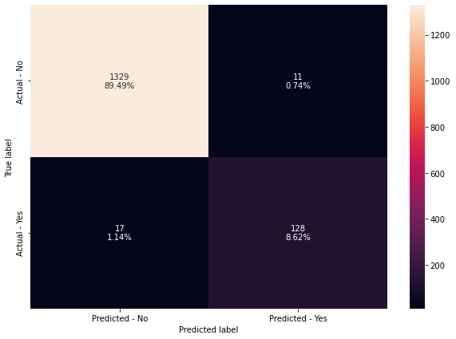

```python
#Confusion matrix
make_confusion_matrix(dTree,y_test)
```

```python
# Recall training and test set

get_recall_score(dTree)
```

```
Recall on training set :  1.0
Recall on test set :  0.8827586206896552
```

```python
# To see feature variables

feature_names = list(X.columns)
print(feature_names)
```

```
['Age', 'Experience', 'Income', 'ZIPCode', 'Family', 'CCAvg', 'Education', 'Mortgage', 'Securities_Account', 'CD_Account', 'Online', 'CreditCard']
```

### To Visualize Decision Tree

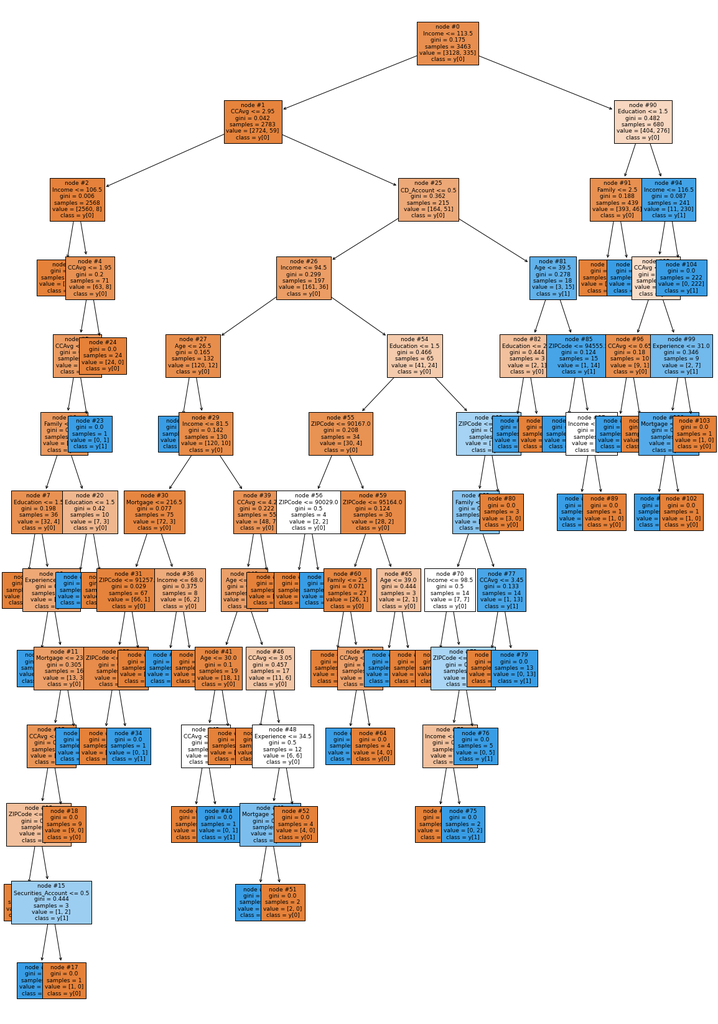

```python
plt.figure(figsize=(20,30))
tree.plot_tree(dTree,feature_names=feature_names,filled=True,fontsize=9,node_ids=True,class_names=True)
plt.show()
```

```python
# Text report showing the rules of a decision tree -

print(tree.export_text(dTree,feature_names=feature_names,show_weights=True))
```

```
|--- Income <= 113.50
|   |--- CCAvg <= 2.95
|   |   |--- Income <= 106.50
|   |   |   |--- weights: [2497.00, 0.00] class: 0
|   |   |--- Income >  106.50
|   |   |   |--- CCAvg <= 1.95
|   |   |   |   |--- CCAvg <= 1.85
|   |   |   |   |   |--- Family <= 3.50
|   |   |   |   |   |   |--- Education <= 1.50
|   |   |   |   |   |   |   |--- weights: [19.00, 0.00] class: 0
|   |   |   |   |   |   |--- Education >  1.50
|   |   |   |   |   |   |   |--- Experience <= 4.50
|   |   |   |   |   |   |   |   |--- weights: [0.00, 1.00] class: 1
|   |   |   |   |   |   |   |--- Experience >  4.50
|   |   |   |   |   |   |   |   |--- Mortgage <= 231.00
|   |   |   |   |   |   |   |   |   |--- CCAvg <= 1.15
|   |   |   |   |   |   |   |   |   |   |--- ZIPCode <= 92901.50
|   |   |   |   |   |   |   |   |   |   |   |--- weights: [3.00, 0.00] class: 0
|   |   |   |   |   |   |   |   |   |   |--- ZIPCode >  92901.50
|   |   |   |   |   |   |   |   |   |   |   |--- truncated branch of depth 2
|   |   |   |   |   |   |   |   |   |--- CCAvg >  1.15
|   |   |   |   |   |   |   |   |   |   |--- weights: [9.00, 0.00] class: 0
|   |   |   |   |   |   |   |   |--- Mortgage >  231.00
|   |   |   |   |   |   |   |   |   |--- weights: [0.00, 1.00] class: 1
|   |   |   |   |   |--- Family >  3.50
|   |   |   |   |   |   |--- Education <= 1.50
|   |   |   |   |   |   |   |--- weights: [0.00, 3.00] class: 1
|   |   |   |   |   |   |--- Education >  1.50
|   |   |   |   |   |   |   |--- weights: [7.00, 0.00] class: 0
|   |   |   |   |--- CCAvg >  1.85
|   |   |   |   |   |--- weights: [0.00, 1.00] class: 1
|   |   |   |--- CCAvg >  1.95
|   |   |   |   |--- weights: [24.00, 0.00] class: 0
|   |--- CCAvg >  2.95
|   |   |--- CD_Account <= 0.50
|   |   |   |--- Income <= 94.50
|   |   |   |   |--- Age <= 26.50
|   |   |   |   |   |--- weights: [0.00, 2.00] class: 1
|   |   |   |   |--- Age >  26.50
|   |   |   |   |   |--- Income <= 81.50
```

[output cut: 99 more lines]

```
|   |   |   |--- CCAvg <= 2.15
|   |   |   |   |--- CCAvg <= 0.65
|   |   |   |   |   |--- weights: [0.00, 1.00] class: 1
|   |   |   |   |--- CCAvg >  0.65
|   |   |   |   |   |--- weights: [9.00, 0.00] class: 0
|   |   |   |--- CCAvg >  2.15
|   |   |   |   |--- Experience <= 31.00
|   |   |   |   |   |--- Mortgage <= 141.50
|   |   |   |   |   |   |--- weights: [0.00, 7.00] class: 1
|   |   |   |   |   |--- Mortgage >  141.50
|   |   |   |   |   |   |--- weights: [1.00, 0.00] class: 0
|   |   |   |   |--- Experience >  31.00
|   |   |   |   |   |--- weights: [1.00, 0.00] class: 0
|   |   |--- Income >  116.50
|   |   |   |--- weights: [0.00, 222.00] class: 1
```

```python
# importance of features in the tree building ( The importance of a feature is computed as the
#(normalized) total reduction of the criterion brought by that feature. It is also known as the Gini importance )

print (pd.DataFrame(dTree.feature_importances_, columns = ["Imp"], index = X_train.columns).sort_values(by = 'Imp', ascending = False))
```

```
                         Imp
Education           0.396818
Income              0.315650
Family              0.141801
CCAvg               0.063097
CD_Account          0.023071
ZIPCode             0.021744
Age                 0.014876
Mortgage            0.011481
Experience          0.009260
Securities_Account  0.002203
Online              0.000000
CreditCard          0.000000
```

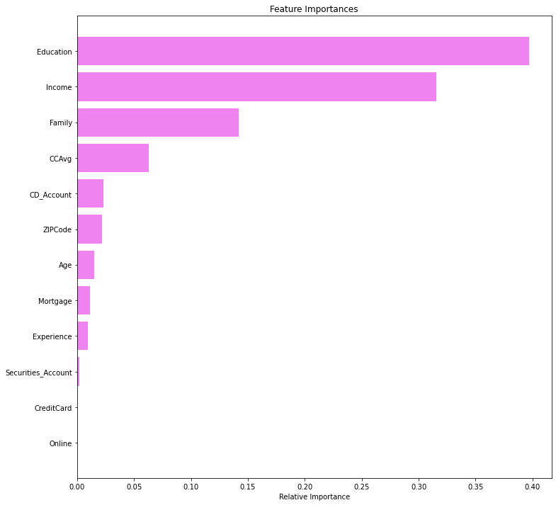

```python
importances = dTree.feature_importances_
indices = np.argsort(importances)

plt.figure(figsize=(12,12))
plt.title('Feature Importances')
plt.barh(range(len(indices)), importances[indices], color='violet', align='center')
plt.yticks(range(len(indices)), [feature_names[i] for i in indices])
plt.xlabel('Relative Importance')
plt.show()
```

- The above tree is complex and it is overfitting. We will try do limit the max_Depth and then we will see best fit by using GridSearch

#### Recalling Overfitting

```python
# Pre-prune the tree using max_depth = 4.
dTree1 = DecisionTreeClassifier(criterion = 'gini',max_depth=4,random_state=1)
dTree1.fit(X_train, y_train)
```

```
DecisionTreeClassifier(max_depth=4, random_state=1)
```

#### Confusion matrix with max_depth = 4

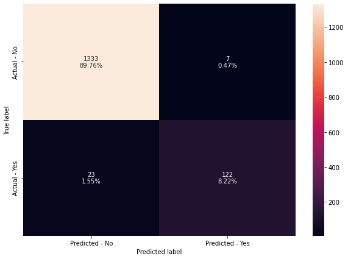

```python
#Confusin matrix with max_depth = 4

make_confusion_matrix(dTree1, y_test)
```

#### Training and testing score after applied max_depth=4

```python
# Accuracy on train and test
print("Accuracy on training set : ",dTree1.score(X_train, y_train))
print("Accuracy on test set : ",dTree1.score(X_test, y_test))
# Recall on train and test
get_recall_score(dTree1)
```

```
Accuracy on training set :  0.9858504187120993
Accuracy on test set :  0.9797979797979798
Recall on training set :  0.8626865671641791
Recall on test set :  0.8413793103448276
```

#### Visualize Decision Tree after applied max_depth=4

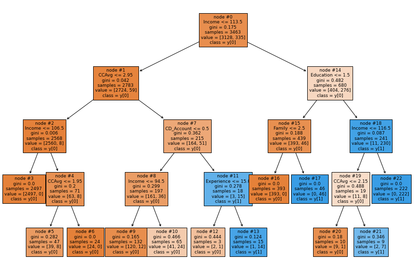

```python
plt.figure(figsize=(15,10))

tree.plot_tree(dTree1,feature_names=feature_names,filled=True,fontsize=9,node_ids=True,class_names=True)
plt.show()
```

```python
# Text report showing the rules of a decision tree with max_depth =4

print(tree.export_text(dTree1,feature_names=feature_names,show_weights=True))
```

```
|--- Income <= 113.50
|   |--- CCAvg <= 2.95
|   |   |--- Income <= 106.50
|   |   |   |--- weights: [2497.00, 0.00] class: 0
|   |   |--- Income >  106.50
|   |   |   |--- CCAvg <= 1.95
|   |   |   |   |--- weights: [39.00, 8.00] class: 0
|   |   |   |--- CCAvg >  1.95
|   |   |   |   |--- weights: [24.00, 0.00] class: 0
|   |--- CCAvg >  2.95
|   |   |--- CD_Account <= 0.50
|   |   |   |--- Income <= 94.50
|   |   |   |   |--- weights: [120.00, 12.00] class: 0
|   |   |   |--- Income >  94.50
|   |   |   |   |--- weights: [41.00, 24.00] class: 0
|   |   |--- CD_Account >  0.50
|   |   |   |--- Experience <= 15.00
|   |   |   |   |--- weights: [2.00, 1.00] class: 0
|   |   |   |--- Experience >  15.00
|   |   |   |   |--- weights: [1.00, 14.00] class: 1
|--- Income >  113.50
|   |--- Education <= 1.50
|   |   |--- Family <= 2.50
|   |   |   |--- weights: [393.00, 0.00] class: 0
|   |   |--- Family >  2.50
|   |   |   |--- weights: [0.00, 46.00] class: 1
|   |--- Education >  1.50
|   |   |--- Income <= 116.50
|   |   |   |--- CCAvg <= 2.15
|   |   |   |   |--- weights: [9.00, 1.00] class: 0
|   |   |   |--- CCAvg >  2.15
|   |   |   |   |--- weights: [2.00, 7.00] class: 1
|   |   |--- Income >  116.50
|   |   |   |--- weights: [0.00, 222.00] class: 1
```

```python
# importance of features in the tree building ( The importance of a feature is computed as the
#(normalized) total reduction of the criterion brought by that feature. It is also known as the Gini importance )

print (pd.DataFrame(dTree1.feature_importances_, columns = ["Imp"], index = X_train.columns).sort_values(by = 'Imp', ascending = False))
```

```
                         Imp
Education           0.422411
Income              0.342236
Family              0.154898
CCAvg               0.050811
CD_Account          0.026259
Experience          0.003385
Age                 0.000000
ZIPCode             0.000000
Mortgage            0.000000
Securities_Account  0.000000
Online              0.000000
CreditCard          0.000000
```

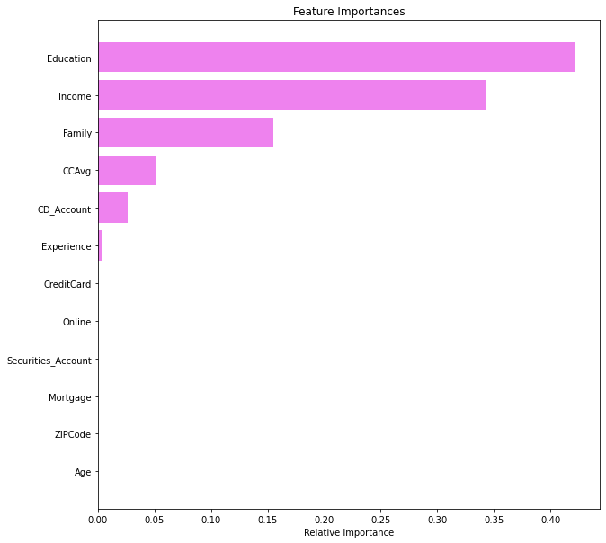

```python
importances = dTree1.feature_importances_
indices = np.argsort(importances)

plt.figure(figsize=(10,10))
plt.title('Feature Importances')
plt.barh(range(len(indices)), importances[indices], color='violet', align='center')
plt.yticks(range(len(indices)), [feature_names[i] for i in indices])
plt.xlabel('Relative Importance')
plt.show()
```

- We have seen the important features Education, Income, Family and CCAvg are top in our previous model. But Pre-prune also showing the same order with excluding the variables Zip code, Age, Mortgage, Securities_Account
- The max_depth recall training set reduced from 1 to 0.86. Hope this is reduced overfitting little.
- We will use gridsearch to see best result by providing various hyperparameters